# Lab 4a

Jas Sur

2/27/2022

## Question 1

Setup data for pressure, temperature and yield

```r
temp <- rep(c(150,160,170), each=6)
pressure <- rep(c(200,215,230), each=3, times=2)
length(pressure)
```

```
## [1] 18
```

```r
yield <- c(90.4, 90.2, 90.1, 90.3,90.5,90.7, 90.7,90.6,90.5,90.6,90.8,90.9,90.2,90.4,89.9,90.1,90.4,90.1)
length(yield)
```

```
## [1] 18
```

```r
chem.process <- data.frame(temp, pressure, yield)
attach(chem.process)
temp <-factor(temp, levels =c(150,160,170), labels=c("150C", "160C", "170C"))
pressure <-factor(pressure, levels =c(200,215,230), labels=c("200Psig","215Psig", "230Psig"))

head(chem.process)
```

|  | temp | pressure | yield |
| --- | --- | --- | --- |
| 1 | 150 | 200 | 90.4 |
| 2 | 150 | 200 | 90.2 |
| 3 | 150 | 200 | 90.1 |
| 4 | 150 | 215 | 90.3 |
| 5 | 150 | 215 | 90.5 |
| 6 | 150 | 215 | 90.7 |

```r
str(chem.process)
```

```
## 'data.frame':    18 obs. of  3 variables:
##  $ temp    : num  150 150 150 150 150 150 160 160 160 160 ...
##  $ pressure: num  200 200 200 215 215 215 230 230 230 200 ...
##  $ yield   : num  90.4 90.2 90.1 90.3 90.5 90.7 90.7 90.6 90.5 90.6 ...
```

### a. Analyze the data and draw conclusions, Use alpha = 0.05

a1. Plotting: boxplot of yield vs temp, yield vs pressure, yeld vs temp and pressure, interaction plot

```r
tapply(yield, list(temp,pressure), mean)
```

```
##       200Psig  215Psig 230Psig
## 150C 90.23333 90.50000      NA
## 160C 90.76667       NA    90.6
## 170C       NA 90.16667    90.2
```

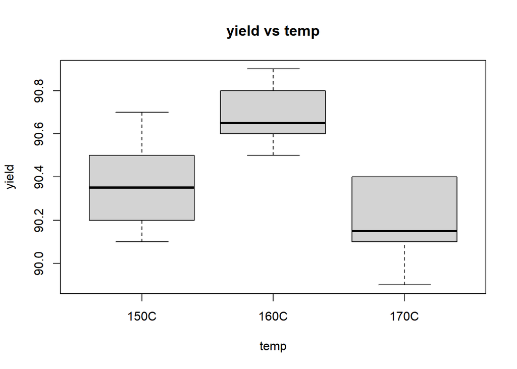

```r
boxplot(yield~temp, main="yield vs temp")
```

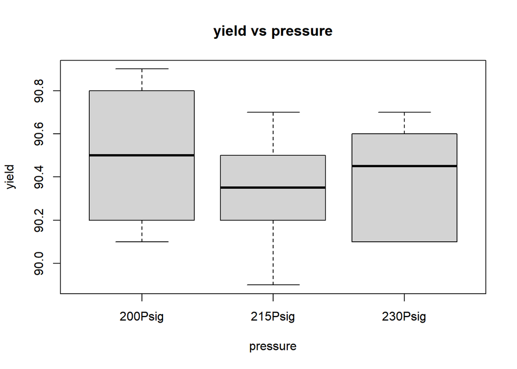

```r
boxplot(yield~pressure, main="yield vs pressure")
```

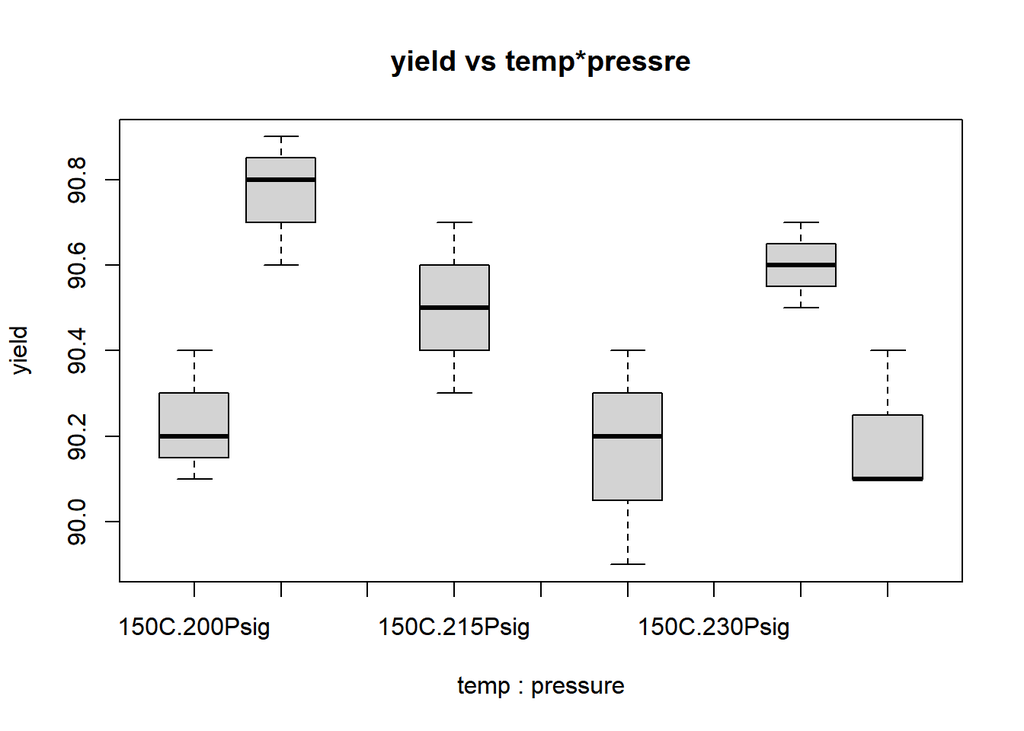

```r
boxplot(yield~temp*pressure, main="yield vs temp*pressre")
```

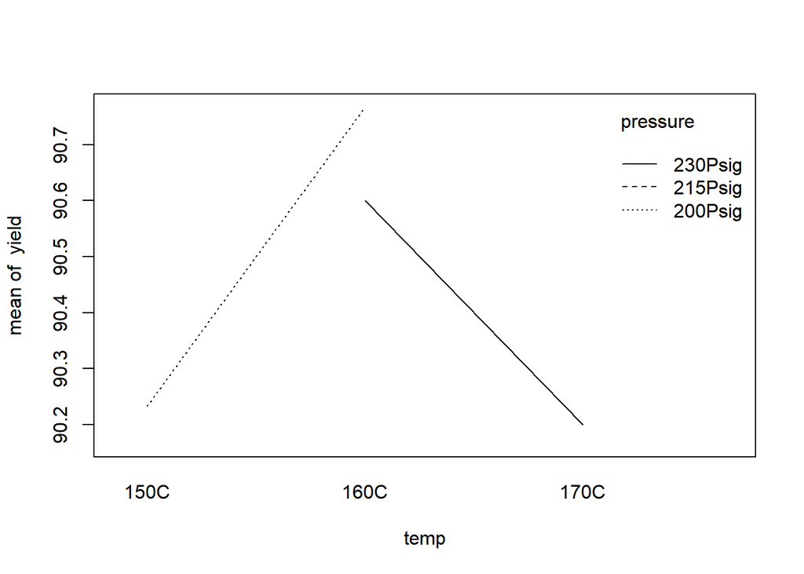

```r
interaction.plot(temp, pressure, yield)
```

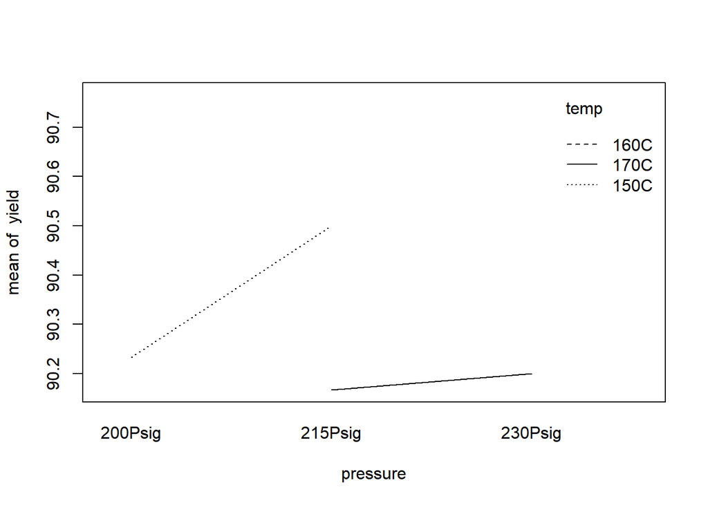

```r
interaction.plot(pressure, temp, yield)
```

Slopes are changing, so there is some kind of interaction

a2. Build a linear model using aov(). Print ANOVA output. Are main factors and interaction factor significant?

```r
chem.process.mod <- aov(yield~temp*pressure)
summary.aov(chem.process.mod)
```

```
##               Df Sum Sq Mean Sq F value  Pr(>F)
## temp           2 0.7678  0.3839  12.123 0.00132 **
## pressure       2 0.0411  0.0206   0.649 0.53991
## temp:pressure  1 0.1089  0.1089   3.439 0.08842 .
## Residuals     12 0.3800  0.0317
## ---
## Signif. codes:  0 '***' 0.001 '**' 0.01 '*' 0.05 '.' 0.1 ' ' 1
```

```r
summary.lm(chem.process.mod)
```

```
##
## Call:
## aov(formula = yield ~ temp * pressure)
##
## Residuals:
##     Min      1Q  Median      3Q     Max
## -0.2667 -0.1000  0.0000  0.1250  0.2333
##
## Coefficients: (3 not defined because of singularities)
##                          Estimate Std. Error t value Pr(>|t|)
## (Intercept)               90.2333     0.1027 878.267   <2e-16 ***
## temp160C                   0.5333     0.1453   3.671   0.0032 **
## temp170C                   0.1333     0.2055   0.649   0.5286
## pressure215Psig            0.2667     0.1453   1.835   0.0914 .
## pressure230Psig           -0.1667     0.1453  -1.147   0.2737
## temp160C:pressure215Psig       NA         NA      NA       NA
## temp170C:pressure215Psig  -0.4667     0.2517  -1.854   0.0884 .
## temp160C:pressure230Psig       NA         NA      NA       NA
## temp170C:pressure230Psig       NA         NA      NA       NA
## ---
## Signif. codes:  0 '***' 0.001 '**' 0.01 '*' 0.05 '.' 0.1 ' ' 1
##
## Residual standard error: 0.178 on 12 degrees of freedom
## Multiple R-squared:  0.7072, Adjusted R-squared:  0.5852
## F-statistic: 5.796 on 5 and 12 DF,  p-value: 0.005996
```

```r
chem.process.nointeraction.mod <- aov(yield~temp+pressure)
anova(chem.process.mod, chem.process.nointeraction.mod)
```

|  | Res.Df | RSS | Df | Sum of Sq | F | Pr(>F) |
| --- | --- | --- | --- | --- | --- | --- |
| 1 | 12 | 0.3800000 | NA | NA | NA | NA |
| 2 | 13 | 0.4888889 | -1 | -0.1088889 | 3.438596 | 0.08841787 |

Since P-value >.05, we accept null and reject Alternate. The interaction term is in-significant, so we can discard the interaction term. We take the partial model instead of full model

a3. Print out regression model with coefficients

```r
summary.lm(chem.process.nointeraction.mod)
```

```
##
## Call:
## aov(formula = yield ~ temp + pressure)
##
## Residuals:
##      Min       1Q   Median       3Q      Max
## -0.34444 -0.10556 -0.02222  0.10556  0.27778
##
## Coefficients:
##                 Estimate Std. Error t value Pr(>|t|)
## (Intercept)     90.31111    0.10221 883.607   <2e-16 ***
## temp160C         0.37778    0.12928   2.922   0.0119 *
## temp170C        -0.17778    0.12928  -1.375   0.1923
## pressure215Psig  0.11111    0.12928   0.859   0.4057
## pressure230Psig -0.01111    0.12928  -0.086   0.9328
## ---
## Signif. codes:  0 '***' 0.001 '**' 0.01 '*' 0.05 '.' 0.1 ' ' 1
##
## Residual standard error: 0.1939 on 13 degrees of freedom
## Multiple R-squared:  0.6233, Adjusted R-squared:  0.5074
## F-statistic: 5.377 on 4 and 13 DF,  p-value: 0.008861
```

Only the intercept and temperature-160C is year significant, so it means that the linear model can remove other terms while predicting the values.

### b. Prepare appropriate residuals plot and comment on the model’s adequecy

```r
summary.lm(chem.process.nointeraction.mod)
```

```
##
## Call:
## aov(formula = yield ~ temp + pressure)
##
## Residuals:
##      Min       1Q   Median       3Q      Max
## -0.34444 -0.10556 -0.02222  0.10556  0.27778
##
## Coefficients:
##                 Estimate Std. Error t value Pr(>|t|)
## (Intercept)     90.31111    0.10221 883.607   <2e-16 ***
## temp160C         0.37778    0.12928   2.922   0.0119 *
## temp170C        -0.17778    0.12928  -1.375   0.1923
## pressure215Psig  0.11111    0.12928   0.859   0.4057
## pressure230Psig -0.01111    0.12928  -0.086   0.9328
## ---
## Signif. codes:  0 '***' 0.001 '**' 0.01 '*' 0.05 '.' 0.1 ' ' 1
##
## Residual standard error: 0.1939 on 13 degrees of freedom
## Multiple R-squared:  0.6233, Adjusted R-squared:  0.5074
## F-statistic: 5.377 on 4 and 13 DF,  p-value: 0.008861
```

```r
summary.aov(chem.process.nointeraction.mod)
```

```
##             Df Sum Sq Mean Sq F value  Pr(>F)
## temp         2 0.7678  0.3839  10.208 0.00216 **
## pressure     2 0.0411  0.0206   0.547 0.59166
## Residuals   13 0.4889  0.0376
## ---
## Signif. codes:  0 '***' 0.001 '**' 0.01 '*' 0.05 '.' 0.1 ' ' 1
```

Only temperature-160C significantly affect the yield cause pvalue for temp is <0.05, so we reject null hypothesis that temp has no affect on the yield and accept that the temperature does affect the yield. The pressure term is not significant so we accept the null hypothesis that the pressure doesn’t affect yield.

### c. Under what condition would you operate this process

```r
tukeys <- TukeyHSD(chem.process.nointeraction.mod)
tukeys
```

```
##   Tukey multiple comparisons of means
##     95% family-wise confidence level
##
## Fit: aov(formula = yield ~ temp + pressure)
##
## $temp
##                 diff         lwr        upr     p adj
## 160C-150C  0.3166667  0.02103659  0.6122967 0.0355055
## 170C-150C -0.1833333 -0.47896341  0.1122967 0.2655996
## 170C-160C -0.5000000 -0.79563007 -0.2043699 0.0017121
##
## $pressure
##                         diff        lwr       upr     p adj
## 215Psig-200Psig  0.083333333 -0.2122967 0.3789634 0.7422331
## 230Psig-200Psig -0.008333333 -0.3039634 0.2872967 0.9969512
## 230Psig-215Psig -0.091666667 -0.3872967 0.2039634 0.6984418
```

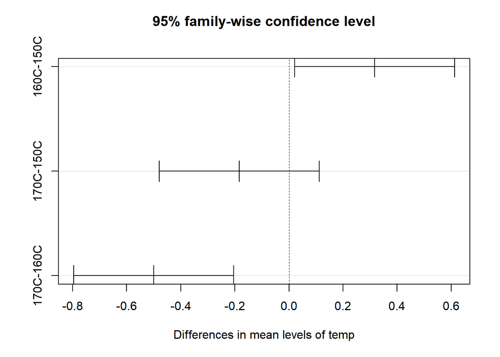

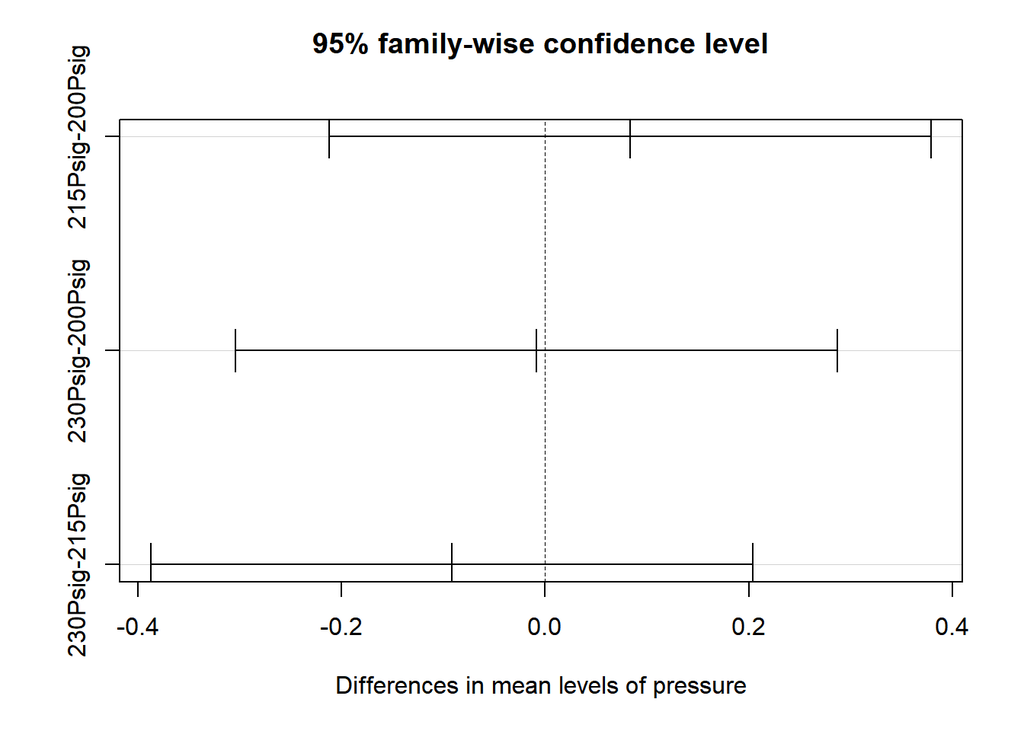

```r
plot(tukeys)
```

Pressure difference of mean is not significant, while temperature difference of mean is significant only for 160C-150C and 170C to 160C

```r
library(agricolae)
lsd <- LSD.test(chem.process.nointeraction.mod, c("temp", "pressure"), console=T)
```

```
##
## Study: chem.process.nointeraction.mod ~ c("temp", "pressure")
##
## LSD t Test for yield
##
## Mean Square Error:  0.03760684
##
## temp:pressure,  means and individual ( 95 %) CI
##
##                 yield       std r      LCL      UCL  Min  Max
## 150C:200Psig 90.23333 0.1527525 3 89.99145 90.47521 90.1 90.4
## 150C:215Psig 90.50000 0.2000000 3 90.25812 90.74188 90.3 90.7
## 160C:200Psig 90.76667 0.1527525 3 90.52479 91.00855 90.6 90.9
## 160C:230Psig 90.60000 0.1000000 3 90.35812 90.84188 90.5 90.7
## 170C:215Psig 90.16667 0.2516611 3 89.92479 90.40855 89.9 90.4
## 170C:230Psig 90.20000 0.1732051 3 89.95812 90.44188 90.1 90.4
##
## Alpha: 0.05 ; DF Error: 13
## Critical Value of t: 2.160369
##
## least Significant Difference: 0.3420705
##
## Treatments with the same letter are not significantly different.
##
##                 yield groups
## 160C:200Psig 90.76667      a
## 160C:230Psig 90.60000      a
## 150C:215Psig 90.50000     ab
## 150C:200Psig 90.23333      b
## 170C:230Psig 90.20000      b
## 170C:215Psig 90.16667      b
```

```r
lsd
```

```
## $statistics
##      MSerror Df     Mean        CV  t.value       LSD
##   0.03760684 13 90.41111 0.2144922 2.160369 0.3420705
##
## $parameters
##         test p.ajusted        name.t ntr alpha
##   Fisher-LSD      none temp:pressure   6  0.05
##
## $means
##                 yield       std r      LCL      UCL  Min  Max   Q25  Q50   Q75
## 150C:200Psig 90.23333 0.1527525 3 89.99145 90.47521 90.1 90.4 90.15 90.2 90.30
## 150C:215Psig 90.50000 0.2000000 3 90.25812 90.74188 90.3 90.7 90.40 90.5 90.60
## 160C:200Psig 90.76667 0.1527525 3 90.52479 91.00855 90.6 90.9 90.70 90.8 90.85
## 160C:230Psig 90.60000 0.1000000 3 90.35812 90.84188 90.5 90.7 90.55 90.6 90.65
## 170C:215Psig 90.16667 0.2516611 3 89.92479 90.40855 89.9 90.4 90.05 90.2 90.30
## 170C:230Psig 90.20000 0.1732051 3 89.95812 90.44188 90.1 90.4 90.10 90.1 90.25
##
## $comparison
## NULL
##
## $groups
##                 yield groups
## 160C:200Psig 90.76667      a
## 160C:230Psig 90.60000      a
## 150C:215Psig 90.50000     ab
## 150C:200Psig 90.23333      b
## 170C:230Psig 90.20000      b
## 170C:215Psig 90.16667      b
##
## attr(,"class")
## [1] "group"
```

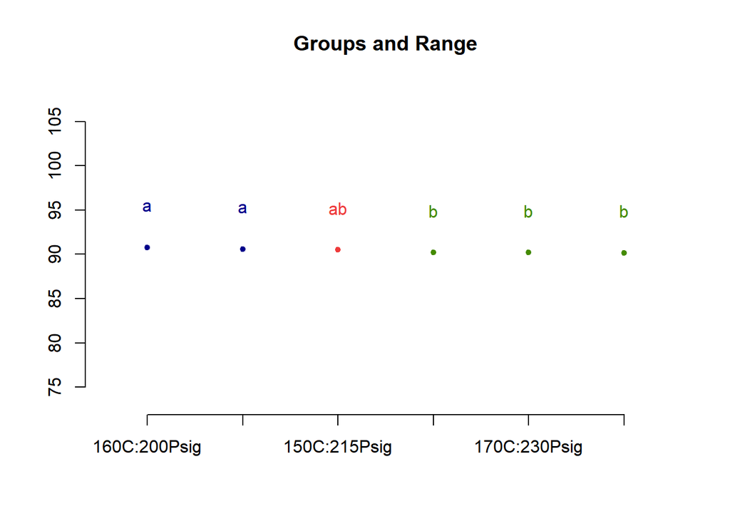

```r
plot(lsd)
```

Based on regression data temperature affect the yield, and the interaction plot 160C has the highest impact on the yield. 160C at 200 Psig and 160C at 230 Psig are the same, so we take the 160C at 200Psig

## Question 2

setup data

```r
operator <- rep(c(1,2,3), each=8)
machine  <- rep(c(1,2,3,4), each=3, times=2)
strength <- c(109, 110,110,112,116,114,110,115,110,111,112,115,108,109,111,109,114,119,110,108,114,112,120,117)
data.frame(operator, machine, strength)
```

| operator | machine | strength |
| --- | --- | --- |
| 1 | 1 | 109 |
| 1 | 1 | 110 |
| 1 | 1 | 110 |
| 1 | 2 | 112 |
| 1 | 2 | 116 |
| 1 | 2 | 114 |
| 1 | 3 | 110 |
| 1 | 3 | 115 |
| 2 | 3 | 110 |
| 2 | 4 | 111 |

[output cut: 14 more lines]